# Data Sources and Data Structures

## Lecture 2

Andrei A. Ternikov

aternikov@hse.ru

## Outline

- Recap
- Developers Documentation
- Data Sources & Data Structures
- Simple ML algorithms
- Tips for Projects
- Workshop 2: Publish to github
- Group work

## Developers Documentation

## Examples

**Libraries (packages):**

- [`numpy`](http://www.numpy.org/) manages arrays (Python)
- [`pandas`](https://pandas.pydata.org/pandas-docs/stable/) manages data frames (Python)
- [`data.table`](https://github.com/Rdatatable/data.table/wiki) works with big data tables (R)
- [`forecast`](https://cran.r-project.org/web/packages/forecast/forecast.pdf) manages time-series data (R)

**Documentation Provides:**

- Description
- Guide of installation
- Functions, parameters, classes …
- MWE (Minimal Working Examples)
- Support & License

## Design

**Formats:**

- `html`-site
- `pdf`-document
- `md` -document

**Markdown**

- is a lightweight markup language with plain text formatting syntax
- file format `*.md`
- supports $\LaTeX$
- embedded into R-studio and Jupyter Notebook
- [Sample Markdown Cheatsheet](https://github.com/adam-p/markdown-here/wiki/Markdown-Cheatsheet)
- [Overleaf](https://www.overleaf.com/) - online $\LaTeX$ editor

## Code Format ([PEP8](https://www.python.org/dev/peps/pep-0008/))

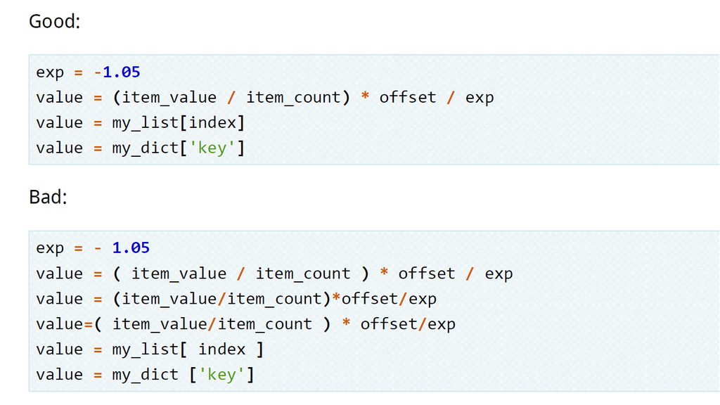

## Data Sources & Data Structures

## Data

[figure not shown]

Source: https://nrootlabs.com/

## HTML Structure

**Hypertext Markup Language (HTML)** is the standard markup language for creating web pages and web applications

**Elements:**

- blocks (`<meta>`, `<head>`, `<body>`)
- tags (`<table>`, `<p>`, `<title>`)
- attributes (`<a href = "link">...</a>`)
- values

[figure not shown]

## XML vs. JSON

[figure not shown]

Source: https://www.sunnyhoi.com/json-vs-xml-format-use-api/

## Simple ML Algorithms

## Classification

[figure not shown]

- Spam-filers
- Language detection
- Search for similar documents

## Support Vector Machine (SVM)

[figure not shown]

Source: medium.com

## Naive Bayes Classifier

[figure not shown]

Source: www.fromthegenesis.com

## Naive Bayes Classifier (a bit math)

**Task:** 3 organizations apply reports different number of reports to be checks by the headquarters: $15$, $10$, $25$ respectively. Probabilities of making reports without mistakes are following: $0.9$, $0.8$, $0.85$. One report has been chosen. Find the probability that this report was written by the second organization.

**Solution:**

Let $A_1$, $A_2$, $A_3$ - events of choosing the report for 3 organizations

So, probabilities: $P(A_1)=\cfrac{15}{50}$, $P(A_2)=\cfrac{10}{50}$, $P(A_3)=\cfrac{25}{50}$

Get full probability: $P(B)=0.9\cdot\cfrac{15}{50}+0.8\cdot\cfrac{10}{50}+0.85\cdot\cfrac{25}{50}=0.855$

Answer: $P(A_2|B)=\cfrac{0.2\cdot 0.8}{0.855}=0.19$

## Regression

[figure not shown]

- Market value prediction
- Demand analysis
- Supply analysis

## Problems

[figure not shown]

Source: medium.com

## Q&A

## Group Work

- Read the article
- Define the goal of research
- Describe what data used
- What measures used for analysis
- Highlight results and managerial implications

**Article:** Wei, X., & Stillwell, D. (2017, February). How Smart Does Your Profile Image Look?: Estimating Intelligence from Social Network Profile Images. In Proceedings of the Tenth ACM International Conference on Web Search and Data Mining (pp. 33-40). ACM.

## Must Read

**Kill your evening and read following articles:**

- Машинное обучение для людей: https://vas3k.ru/blog/machine_learning/
- ML for Humans: https://medium.com/machine-learning-for-humans (in English)